# compressor_fouling_eda

%load_ext autoreload %autoreload 2

```python
from pathlib import Path
from typing import Literal
import warnings

import arviz_plots as azp
import matplotlib.pyplot as plt
import numpy as np
import pandas as pd
import seaborn as sns
from sklearn.feature_selection import mutual_info_regression
from sklearn.preprocessing import StandardScaler

from compressor_fouling_modeling.utility import (
    calculate_data_masks,
    plot_timeseries_grid,
    prepare_model_input,
    visualize_correlations,
    visualize_imputation,
)

azp.style.use("dark_background")  # pick style of interest
%config InlineBackend.figure_format = 'retina'  # high resolution figures
warnings.filterwarnings("ignore")
```

```python
RANDOM_SEED = 14
rng = np.random.default_rng(RANDOM_SEED)
```

```python
# Define project root relative to notebook location
PROJECT_ROOT = Path().resolve().parents[0]  # goes up one level from /notebooks/
IMAGE_DIR = Path(PROJECT_ROOT / "results" / "plots")
DATA_DIR = PROJECT_ROOT / "data"
```

```python
# Check if the directory exists and create it if it doesn't
if not IMAGE_DIR.exists():
    try:
        IMAGE_DIR.mkdir(parents=True, exist_ok=True)
        print(f"Directory '{IMAGE_DIR}' created successfully.")
    except Exception as e:
        print(f"An error occurred: {e}")
else:
    print(f"Directory '{IMAGE_DIR}' already exists.")
```

```
Directory '/home/mghanava/Projects/DataScience/projects/compressor_fouling_modeling/results/plots' created successfully.
```

```python
# Load file
data_raw = pd.read_csv(DATA_DIR / "raw" / "ds_compressor_data.csv")
data_raw["timestamp"] = pd.to_datetime(data_raw["timestamp"], utc=True)
data_raw = data_raw.set_index("timestamp").sort_index()
print(f"Data covers period of {data_raw.index.min()} to {data_raw.index.max()} with {data_raw.index.diff().mean()} frequency.")
```

```
Data covers period of 2024-08-01 00:00:00+00:00 to 2025-03-30 00:00:00+00:00 with 1 days 00:00:00 frequency.
```

```python
data_raw.iloc[:, 3].astype(float)
```

```
timestamp
2024-08-01 00:00:00+00:00    50.0
2024-08-02 00:00:00+00:00    50.0
2024-08-03 00:00:00+00:00    50.0
2024-08-04 00:00:00+00:00    50.0
2024-08-05 00:00:00+00:00    50.0
                             ...
2025-03-26 00:00:00+00:00    40.0
2025-03-27 00:00:00+00:00    40.0
2025-03-28 00:00:00+00:00    40.0
2025-03-29 00:00:00+00:00    40.0
2025-03-30 00:00:00+00:00    40.0
Name: Outlet_Flow_Rate_SP, Length: 242, dtype: float64
```

```python
# convert (and overwrite) int datatype to float to avoid implicit rounding with NumPy arrays or even errors with newer pandas versions
data_raw.isetitem(3, data_raw.iloc[:, 3].astype(float))
data_raw.isetitem(4, data_raw.iloc[:, 4].astype(float))
```

Off_Gas_Fraction_Percentage: This represents the percentage of off-gas (or residual gas) in the system. Off-gas is the gas that is not fully compressed or utilized and can affect the efficiency and output of the compressor.

Outlet_Flow_Rate_SP: This stands for the Set Point (SP) for the outlet flow rate. A set point is a target value that the system aims to maintain. In this case, it's the desired flow rate of the gas or fluid exiting the compressor.

Outlet_Pressure_SP: Similar to the outlet flow rate SP, this is the set point for the pressure at the compressor's outlet. It's the target pressure that the system strives to achieve.

Outlet_Flow_Rate: This is the actual flow rate of the gas or fluid exiting the compressor. It can be compared to the set point (Outlet_Flow_Rate_SP) to evaluate the compressor's performance.

Outlet_Pressure: This column records the actual pressure of the gas or fluid at the compressor's outlet. It can be compared to the set point (Outlet_Pressure_SP) to assess how well the compressor is maintaining the desired pressure.

```python
type(Path(IMAGE_DIR / "data_time_series.png"))
```

```
pathlib._local.PosixPath
```

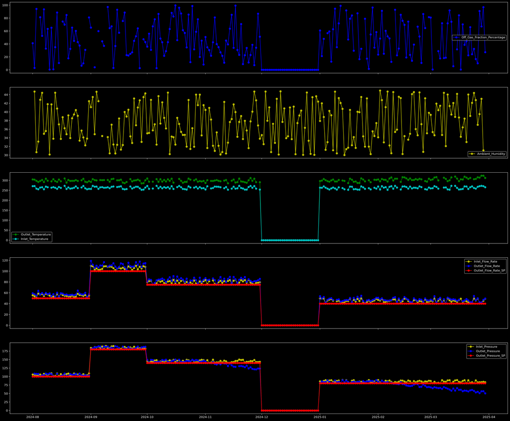

```python
plot_config = [
    [("Off_Gas_Fraction_Percentage", "b")],
    [("Ambient_Humidity", "y")],
    [("Outlet_Temperature", "g"), ("Inlet_Temperature", "c")],
    [("Inlet_Flow_Rate", "y"), ("Outlet_Flow_Rate", "b"), ("Outlet_Flow_Rate_SP", "r")],
    [("Inlet_Pressure", "y"), ("Outlet_Pressure", "b"), ("Outlet_Pressure_SP", "r")],
]
fname = Path(IMAGE_DIR / "data_time_series.png")
plot_timeseries_grid(data_raw, plot_config, save=True, fname=fname)
```

```
Outlet_Temperature             0.120773
Inlet_Temperature              0.106280
Off_Gas_Fraction_Percentage    0.091787
Outlet_Pressure                0.028986
Ambient_Humidity               0.024155
Inlet_Pressure                 0.004831
Outlet_Pressure_SP             0.000000
Outlet_Flow_Rate_SP            0.000000
Inlet_Flow_Rate                0.000000
Outlet_Flow_Rate               0.000000
dtype: float64
```

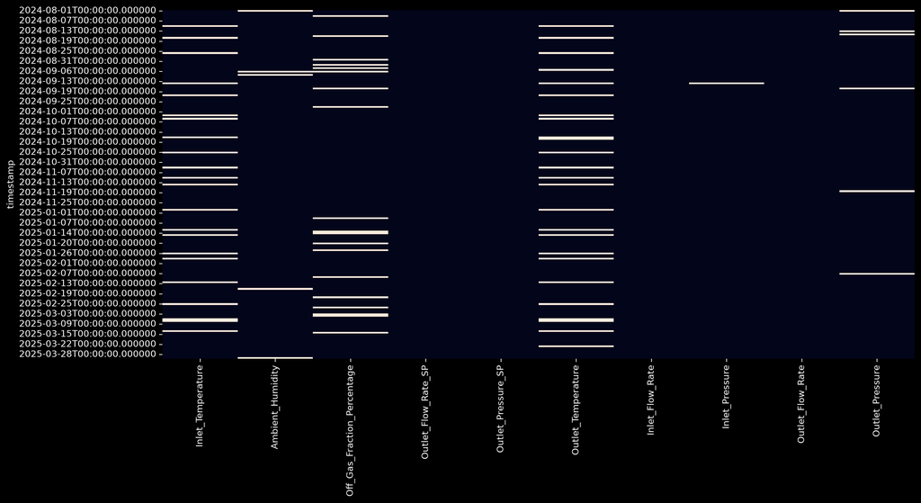

```python
data_nonzero_setpoints = data_raw[data_raw["Outlet_Flow_Rate"] > 0]
fig, ax = plt.subplots(1, 1, figsize=(15, 7))
sns.heatmap(data_nonzero_setpoints.isna(), cbar=False, ax=ax)
display(data_nonzero_setpoints.isna().mean().sort_values(ascending=False))
plt.show()
plt.close(fig)
del fig, ax
```

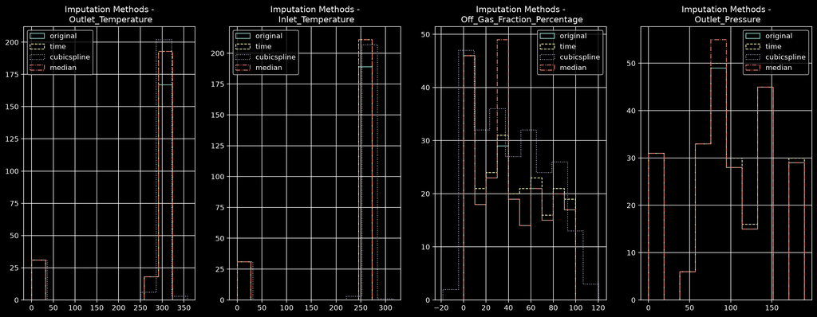

```python
fig, axs = plt.subplots(1, 4, figsize=(20, 7))
visualize_imputation(axs[0], data_raw, feature="Outlet_Temperature")
visualize_imputation(axs[1], data_raw, feature="Inlet_Temperature")
visualize_imputation(axs[2], data_raw, feature="Off_Gas_Fraction_Percentage")
visualize_imputation(axs[3], data_raw, feature="Outlet_Pressure")
plt.show()
plt.close(fig)
del fig, axs
```

Avoid: Mean/median imputation - destroys temporal relationships in process data. The time method does a better job by simply interpolating missing values within number of consecutive NaNs to fill. I initially drop rows with missing Outlet_Pressure as the target with limited missing values and replace missing values through simple interpolate method ('time') that preserves distributions (temporal relationships) to a great extent.

```python
data, X, y = prepare_model_input(data_raw, None, feature_engineering_allowed=True)
```

```python
baseline_mask, shutin_mask = calculate_data_masks(
    data
)
X_baseline = X.loc[baseline_mask]
y_baseline = y.loc[baseline_mask]
```

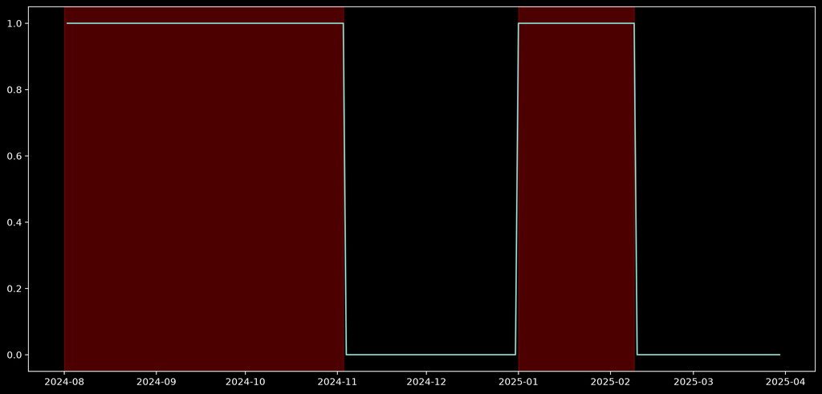

```python
baseline = [("2024-08-01", "2024-11-03"), ("2025-01-01", "2025-02-09")]
fig, ax = plt.subplots(1, 1, figsize=(15, 7))
ax.plot(baseline_mask * 1)
for start, end in baseline:
    ax.axvspan(start, end, color="red", alpha=0.3)
plt.show()
plt.close(fig)
del fig, ax
```

### Investigate correlations

```python
data_baseline = data.loc[baseline_mask]
```

```
pearson
```

```
Outlet_Pressure                1.000000
Outlet_Pressure_SP             0.997299
Outlet_Flow_Rate_SP            0.996474
Inlet_Pressure                 0.994905
Inlet_Flow_Rate                0.988234
Temp_x_Flow                    0.987086
Inlet_Pressure_x_Flow          0.985573
Outlet_Flow_Rate               0.985225
Temperature_Rise              -0.320304
Inlet_Temperature              0.164146
Off_Gas_Fraction_Percentage   -0.084845
Ambient_Humidity               0.032628
Outlet_Temperature            -0.008911
Name: Outlet_Pressure, dtype: float64
```

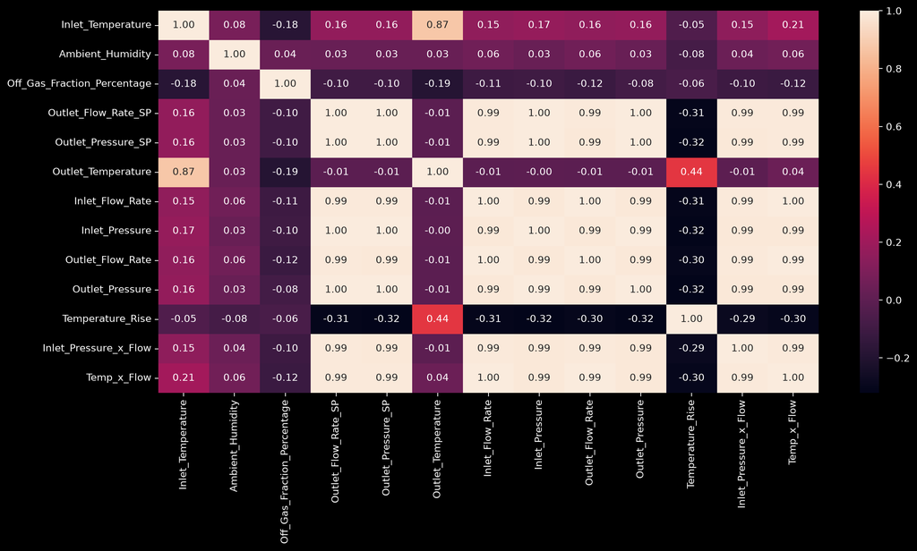

```
kendall
```

```
Outlet_Pressure                1.000000
Outlet_Flow_Rate_SP            0.866731
Outlet_Pressure_SP             0.866731
Inlet_Pressure                 0.768873
Inlet_Pressure_x_Flow          0.733095
Inlet_Flow_Rate                0.731664
Temp_x_Flow                    0.725939
Outlet_Flow_Rate               0.725701
Temperature_Rise              -0.239117
Inlet_Temperature              0.118664
Off_Gas_Fraction_Percentage   -0.035897
Ambient_Humidity               0.027788
Outlet_Temperature             0.007275
Name: Outlet_Pressure, dtype: float64
```

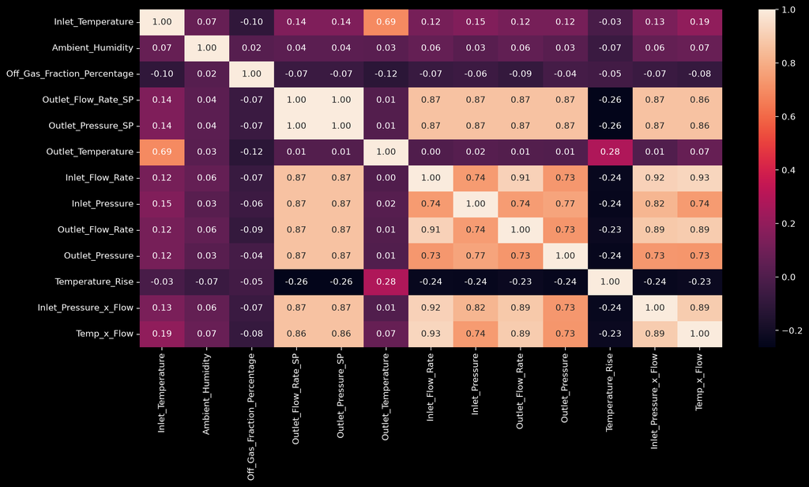

```
spearman
```

```
Outlet_Pressure                1.000000
Outlet_Flow_Rate_SP            0.966474
Outlet_Pressure_SP             0.966474
Inlet_Pressure                 0.941460
Inlet_Pressure_x_Flow          0.927908
Inlet_Flow_Rate                0.925543
Temp_x_Flow                    0.923506
Outlet_Flow_Rate               0.923375
Temperature_Rise              -0.346669
Inlet_Temperature              0.168843
Off_Gas_Fraction_Percentage   -0.050922
Ambient_Humidity               0.040506
Outlet_Temperature             0.007808
Name: Outlet_Pressure, dtype: float64
```

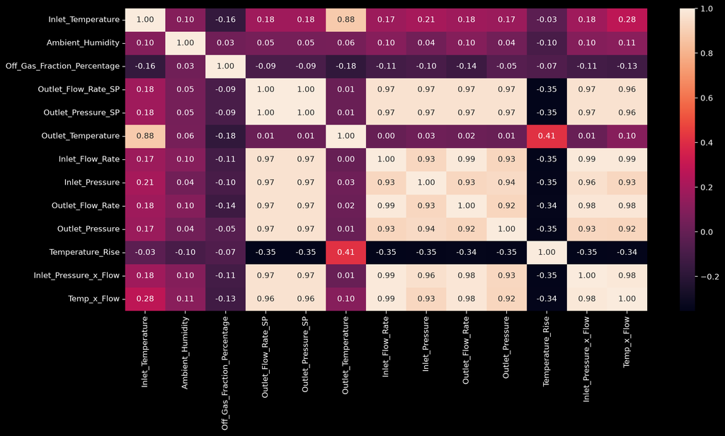

```python
correlation_methods: list[Literal["pearson", "kendall", "spearman"]] = [
    "pearson",
    "kendall",
    "spearman",
]
for corr_method in correlation_methods:
    fig, ax = plt.subplots(1, 1, figsize=(15, 7))
    sns.heatmap(data_baseline.corr(method=corr_method), annot=True, fmt=".2f", ax=ax)
    print(corr_method)
    display(
        data_baseline.corr(method=corr_method)["Outlet_Pressure"].sort_values(
            ascending=False, key=abs
        )
    )
    plt.show()
    plt.close(fig)
    del fig, ax
```

```python
scaler = StandardScaler()
data_baseline_scaled = pd.DataFrame(
    scaler.fit_transform(data_baseline),
    columns=data_baseline.columns,
    index=data_baseline.index,
)
target_mask = data_baseline_scaled.columns != "Outlet_Pressure"
mi_scores = mutual_info_regression(
    data_baseline_scaled.loc[:, target_mask],
    data_baseline_scaled["Outlet_Pressure"],
)
mi_series = pd.Series(
    mi_scores, index=data_baseline_scaled.columns[target_mask]
).sort_values(ascending=False)
print("Mutual Information Scores:")
print(mi_series)
```

```
Mutual Information Scores:
Inlet_Pressure_x_Flow          1.419672
Inlet_Pressure                 1.393253
Outlet_Flow_Rate_SP            1.388929
Outlet_Pressure_SP             1.388929
Temp_x_Flow                    1.348234
Inlet_Flow_Rate                1.318942
Outlet_Flow_Rate               1.225120
Temperature_Rise               0.252270
Ambient_Humidity               0.019486
Off_Gas_Fraction_Percentage    0.011448
Outlet_Temperature             0.004965
Inlet_Temperature              0.000000
dtype: float64
```

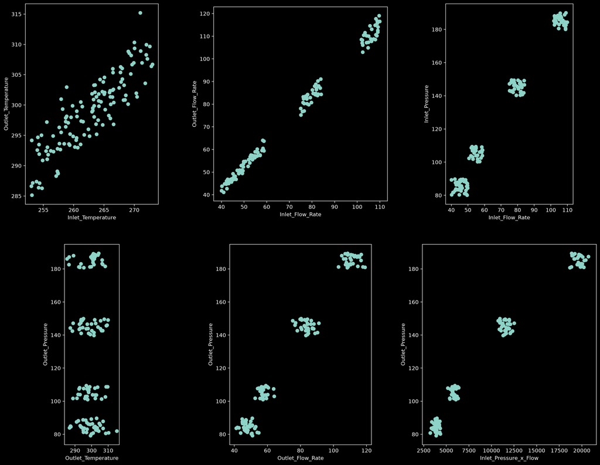

```python
fig, axs = plt.subplots(2, 3, figsize=(20, 15))
visualize_correlations(
    axs[0, 0], data_baseline, "Inlet_Temperature", "Outlet_Temperature"
)
visualize_correlations(axs[0, 1], data_baseline, "Inlet_Flow_Rate", "Outlet_Flow_Rate")
visualize_correlations(axs[0, 2], data_baseline, "Inlet_Flow_Rate", "Inlet_Pressure")
visualize_correlations(
    axs[1, 0], data_baseline, "Outlet_Temperature", "Outlet_Pressure"
)
visualize_correlations(axs[1, 1], data_baseline, "Outlet_Flow_Rate", "Outlet_Pressure")
# non-linear variable
visualize_correlations(
    axs[1, 2], data_baseline, "Inlet_Pressure_x_Flow", "Outlet_Pressure", aspect="auto"
)

plt.show()
plt.close(fig)
del fig, axs
```

# save data for analysis

```python
X_baseline.to_csv(DATA_DIR / "processed" / "X_baseline.csv")
y_baseline.to_csv(DATA_DIR / "processed" / "y_baseline.csv")
X.to_csv(DATA_DIR / "processed" / "X_full.csv")
y.to_csv(DATA_DIR / "processed" / "y_full.csv")
baseline_mask.to_csv(DATA_DIR / "processed" / "baseline_mask.csv")
shutin_mask.to_csv(DATA_DIR / "processed" / "shutin_mask.csv")
```

### Strategy: "Expected vs. Actual" (Residual Analysis)

The core challenge, as stated, is that "outlet pressure is influenced by multiple operating parameters." Therefore, we cannot simply set a hard threshold (e.g., "Alert if pressure < 50 psi") because the pressure changes based on the set point (SP) and inlet conditions.

Since we need to isolate the fouling effect from normal operating changes, the best approach is to build a Virtual Sensor (Regression Model) which solves the specific "Isolating Effects" problem by including Setpoints, Flow, Inlet Pressure, Temperature, ... as inputs. The model "knows" that pressure should drop if flow drops. It won't flag that as a fouling status. It will only flag when pressure drops unaccountably. We train a model to predict what the Outlet Pressure should be given the current inlet conditions and set points. In other words, we need a baseline estimator. Since the machine is controlled, Outlet Pressure ~ Setpoint is over 90% of the answer. We need a linear regression to adjust that baseline slightly based on other operating variables:

- $\text{Output} \approx \text{Setpoint} + \text{Efficiency\_Correction}$

Hypothesis: If the machine is clean, Actual Pressure ≈ Predicted Pressure. Fouling Signal: If the machine is fouling, Actual Pressure < Predicted Pressure. The gap between them (the residual) is the fouling indicator.

The Solution: Take very important note that we treat this as a Physics Problem, not a Forecasting Problem. We are building a Virtual Sensor, not a Stock Market Predictor.

We use the classical regression model, to only allow the dependent variable to be influenced by current values of the independent variables (The model is "blind" to the past). The fact that we broke the autocorrelation link (by removing lags) is exactly what makes this an anomaly detector.

1. Inputs (X): Setpoint is still 100. Flow is still 50.
2. The "Physics" Model: Looks at X. Says: "Based on Flow 50 and SP 100, the pressure MUST be 100."
3. The Reality (Y): The machine is fouled. Actual pressure is 80.
4. The Residual: 100 − 80 = +20 (Anomaly Detected!)

Contrast this with the "Autocorrelated/Forecasting" Model:

1. Inputs $Y_{t−1}$: The pressure 1 day ago was 100.
2. The "Lazy" Model: Looks at $Y_{t−1}$ and says: "Since it was 100 a day ago, it's probably 100 now."
3. The Residual: 100 − 100 = 0 (Anomaly Missed!)

Note that we have 4 pressure and flow setpoints (disregard the shutin period). The physics of the compressor $ \text{Pressure} = f\left(\text{Setpoint}, \text{Flow}, \text{Temp}, \dots \right) $ does not change from day to day (data sample intervals) and from setpoint to setpoint. Therefore, we shuffle the data for validation (and to break autocorrelation) as we want to assure model has learned pure physics. This ensures that every training fold contains a mix of all the four setpoints .

### Summary for the Stakeholder

"We will build a digital twin of the compressor using historical 'healthy' data. This model will predict what the outlet pressure should be based on current operating conditions (flow, temperature, inlet pressure). We will then track the deviation between the model's prediction and the actual sensor reading. A growing deviation indicates fouling, allowing us to alert maintenance before efficiency drops below critical levels."